# 01_DataLoading

Niklas Jocher

2025-11-19

# Set global chunk options

```r
knitr::opts_chunk$set(echo = TRUE, warning = FALSE, message = FALSE)
library(tidyverse)
```

# Introduction

This R Markdown document demonstrates loading, inspecting, and visualizing EEG amplitude data from a CSV file. We will perform the following steps:

```
1 Load the dataset.

2 Inspect the data.

3 Filter data for a single subject.

4 Plot amplitude over time by condition.

5 Compute and visualize average amplitude per subject.

6 Compute the grand average across all subjects.

7 Loop through the first 5 subjects and visualize their individual data.
```

# 1. Load the CSV

```r
data_path <- "/Users/niklasjocher/Desktop/ES data/ga_df_dist2.csv"
df_dist2 <- read_csv(data_path)
```

# 2. Inspect the Data

Let’s look at the first few rows to understand the structure:

```r
head(df_dist2)
```

```
## # A tibble: 6 × 5
##    ...1 subject_id condition    time Amplitude
##   <dbl>      <dbl> <chr>       <dbl>     <dbl>
## 1     0          0 distractor1 -0.25 0.0000215
## 2     1          0 distractor1 -0.24 0.0000303
## 3     2          0 distractor1 -0.23 0.0000319
## 4     3          0 distractor1 -0.22 0.0000342
## 5     4          0 distractor1 -0.21 0.0000379
## 6     5          0 distractor1 -0.2  0.0000324
```

# 3. Filter for Subject 0

Now we want to look at the data for one subject only. To do this we create a new data frame and filter df_dist2 for our desired subject_id. In this case we choose subject_id = 0.

```r
df_dist_subj0 <- df_dist2 %>% filter(subject_id == 0)
```

# 4. Plot Amplitude Over Time by Condition (Subject 0)

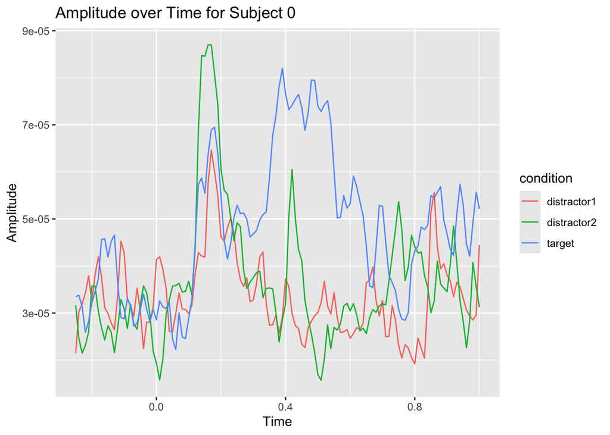

```r
ggplot(df_dist_subj0, aes(x = time, y = Amplitude, color = condition)) +
geom_line() +
labs(title = "Amplitude over Time for Subject 0",
x = "Time",
y = "Amplitude")
```

# 5. Compute Average Amplitude per Subject and Time

```r
df_avg <- df_dist2 %>%
group_by(subject_id, time) %>%
summarise(Amplitude = mean(Amplitude, na.rm = TRUE)) %>%
ungroup()
```